# ps1

JIHYE JANG

1/11/2018

# 1 1 R for Data Science Exercises

## 1.1 1.1 Intro

1. Who did you work with? Annie Gao, Guillermo Ortiz

## 1.2 1.2 - 3.6.1

1. What geom would you use to draw a line chart? A boxplot? A histogram? An area chart? geom_smooth(), geom_boxplot(), geom_histogram(), geom_area()
2. What does show.legend = FALSE do? What happens if you remove it? Why do you think I used it earlier in the chapter? it is a logical code, decides if this layer should be included or not. NA, the default, includes if any aesthetics are mapped. FALSE never includes, and TRUE always includes.  
   Because it is redundant sometimes when the graph itself is very clear
3. What does the se argument to geom_smooth() do? display confidence interval around smooth (TRUE by default, use level to control)
4. Will these two graphs look different? Why/why not?

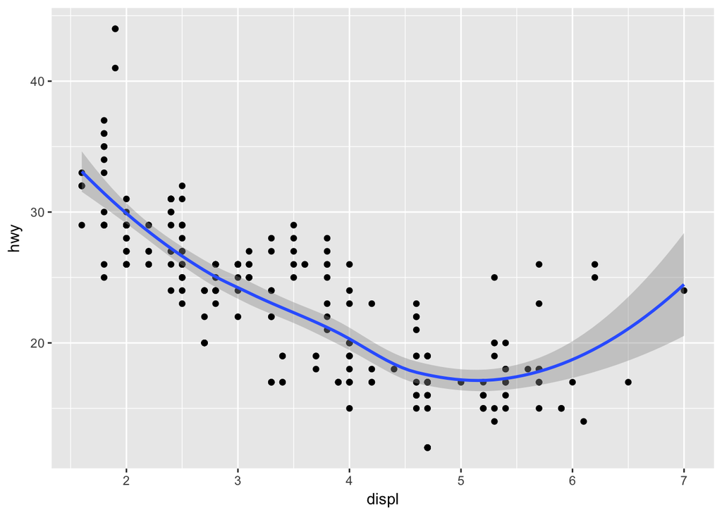

```r
library(ggplot2)
ggplot(data = mpg, mapping = aes(x = displ, y = hwy)) +
  geom_point() +
  geom_smooth()
```

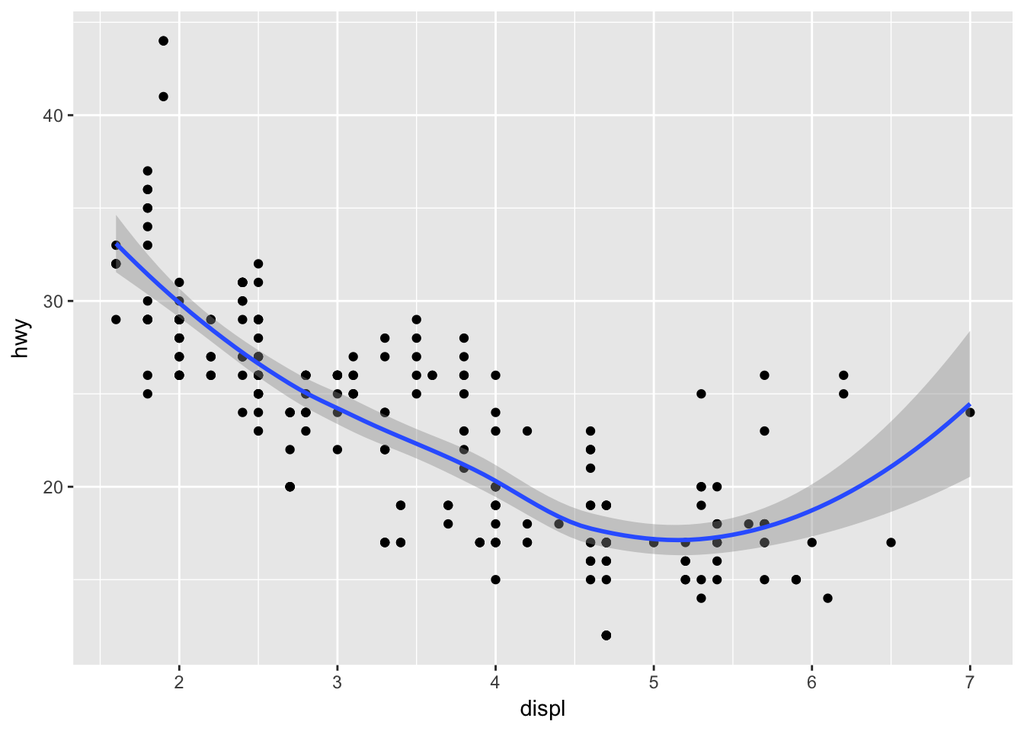

```r
ggplot() +
  geom_point(data = mpg, mapping = aes(x = displ, y = hwy)) +
  geom_smooth(data = mpg, mapping = aes(x = displ, y = hwy))
```

they are the same. the only difference is that the first one specified mapping in ggplot, the second one did seprately in geom_point() and geom_smooth()

## 1.3 1.2.1 - 3.7.1

1. What is the default geom associated with stat_summary()? How could you rewrite the previous plot to use that geom function instead of the stat function? The default is geom_pointrange().

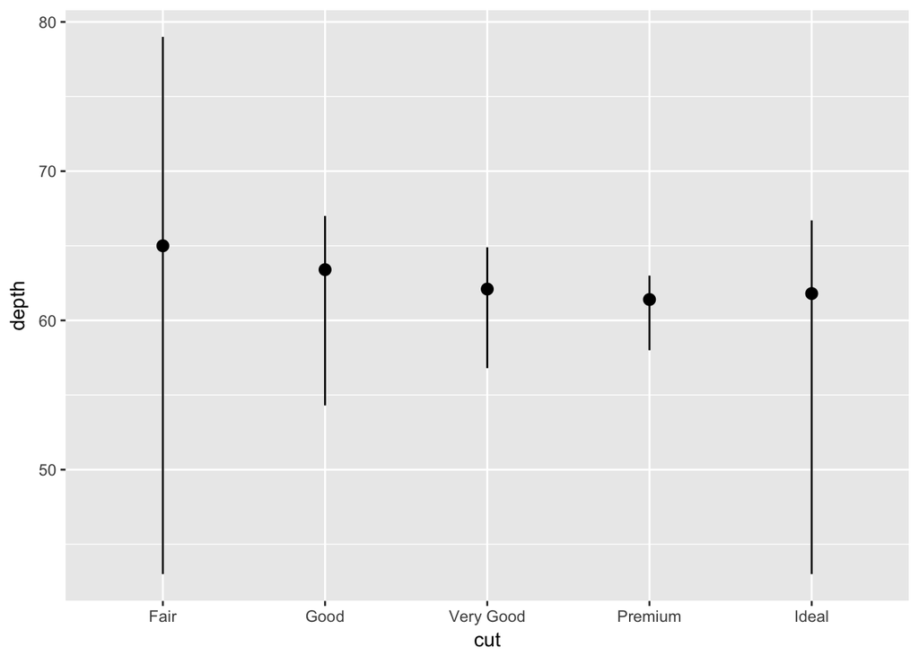

```r
ggplot(data = diamonds) +
  geom_pointrange(mapping = aes(x = cut, y = depth),
                  stat = "summary",
                  fun.ymin = min,
                  fun.ymax = max,
                  fun.y = median)
```

2. What does geom_col() do? How is it different to geom_bar()? In the geom_col(), the heights of the bars represent values in the data.In the contrary, geom_bar makes the height of the bar proportional to the number of cases in each group. geom_bar uses stat_count by default: it counts the number of cases at each x position. geom_col uses stat_identity Thus, geom_bar(stat = “identity”) and geom_col() are the same.
3. Most geoms and stats come in pairs that are almost always used in concert. Read through the documentation and make a list of all the pairs. What do they have in common? geom_bar / stat_count geom_boxplot/ stat_boxplot geom_count / stat_sum geom_smooth / stat_summary

they often work as each other’s layer

such as following: geom_bar(mapping = NULL, data = NULL, stat = “count”, position = “stack”, …, width = NULL, binwidth = NULL, na.rm = FALSE, show.legend = NA, inherit.aes = TRUE)

4. What variables does stat_smooth() compute? What parameters control its behaviour? Computed variables y-predicted value ymin-lower pointwise confidence interval around the mean ymax-upper pointwise confidence interval around the mean se-standard error

parameter: method, formula, se, na.rm, show.legend, inherit.aes, span, level, etc. See ?stat_smooth

5. In our proportion bar chart, we need to set group = 1. Why? In other words what is the problem with these two graphs?

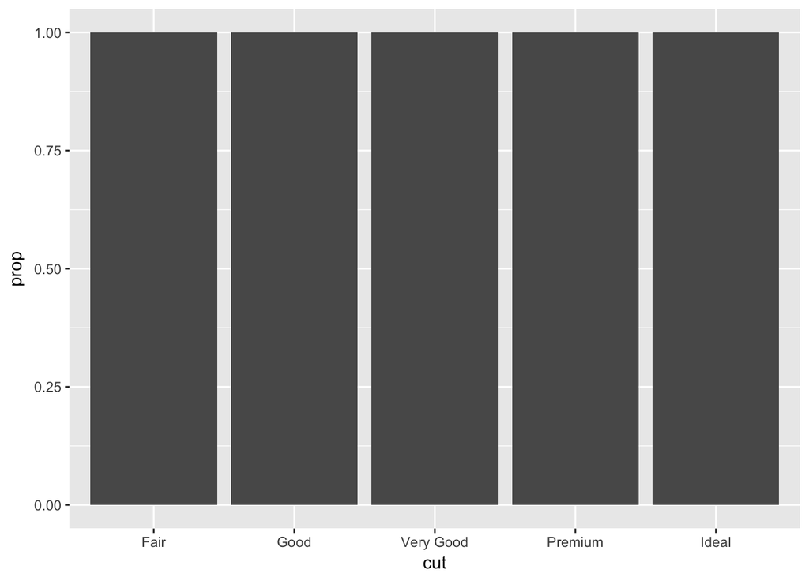

```r
ggplot(data = diamonds) +
  geom_bar(mapping = aes(x = cut, y = ..prop..))
```

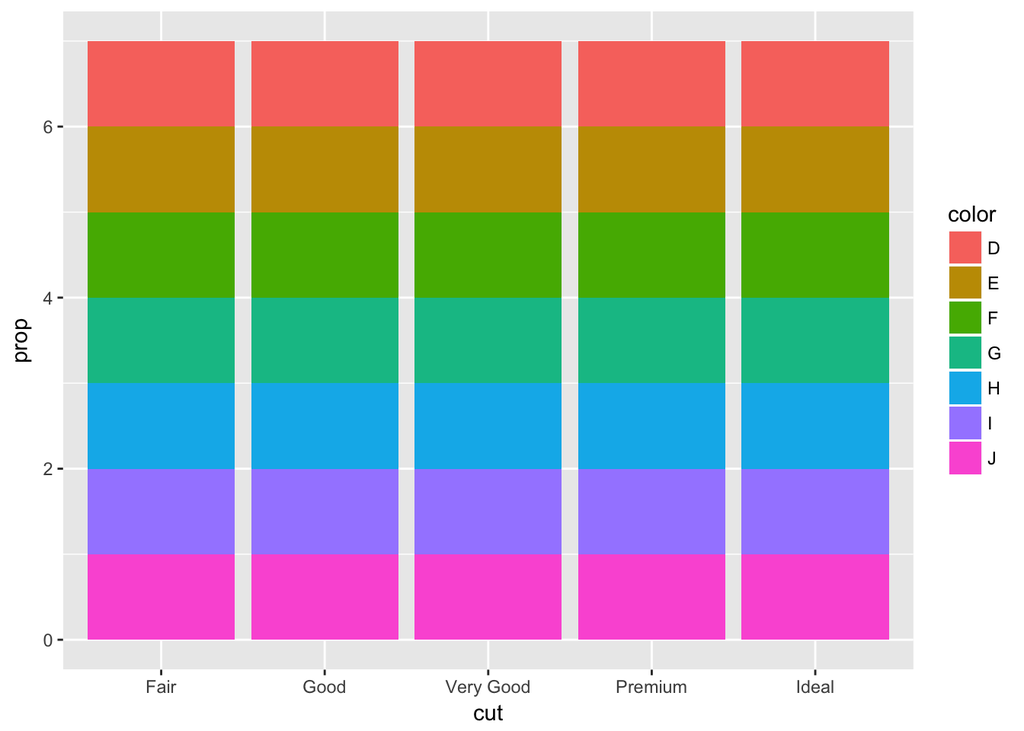

```r
ggplot(data = diamonds) +
  geom_bar(mapping = aes(x = cut, fill = color, y = ..prop..))
```

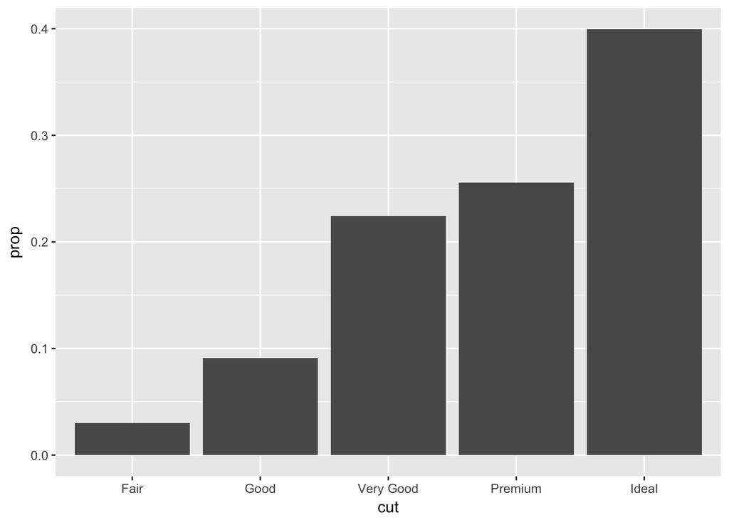

```r
ggplot(data = diamonds) +
  geom_bar(mapping = aes(x = cut, fill = color, y = ..prop.., group = 1))
```

without group = 1, the graphs show the sum (no sub-graphs based on the variation of group) so they do not give the grapgh with proportional representations that we want.

## 1.4 1.3 - 3.8.1

1. What is the problem with this plot? How could you improve it?

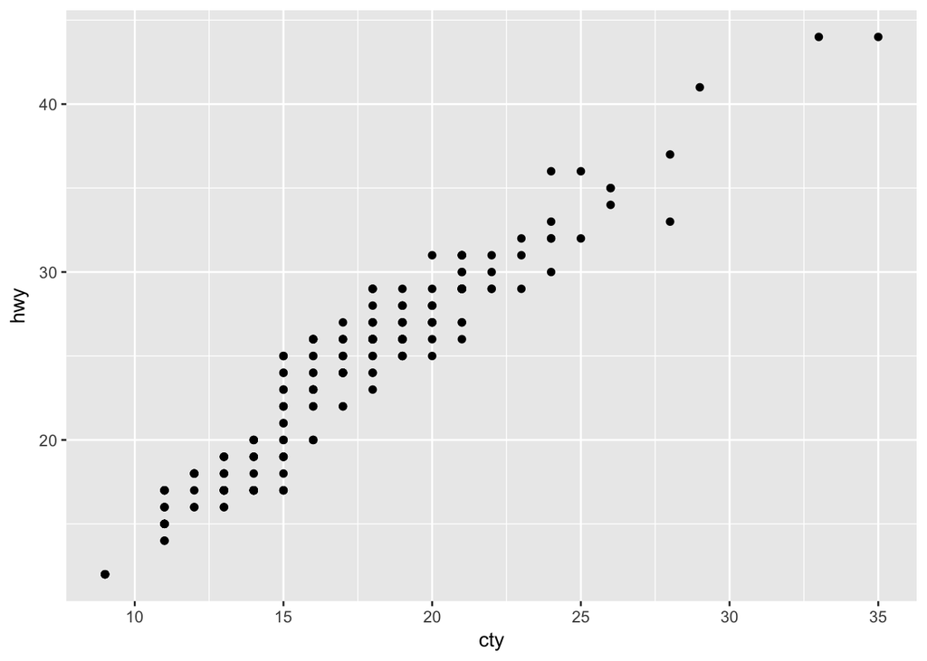

```r
ggplot(data = mpg, mapping = aes(x = cty, y = hwy)) +
  geom_point()
```

the number of points are little compared to the dataset, it is because many points overlap. we can use geom_jitter() instead.

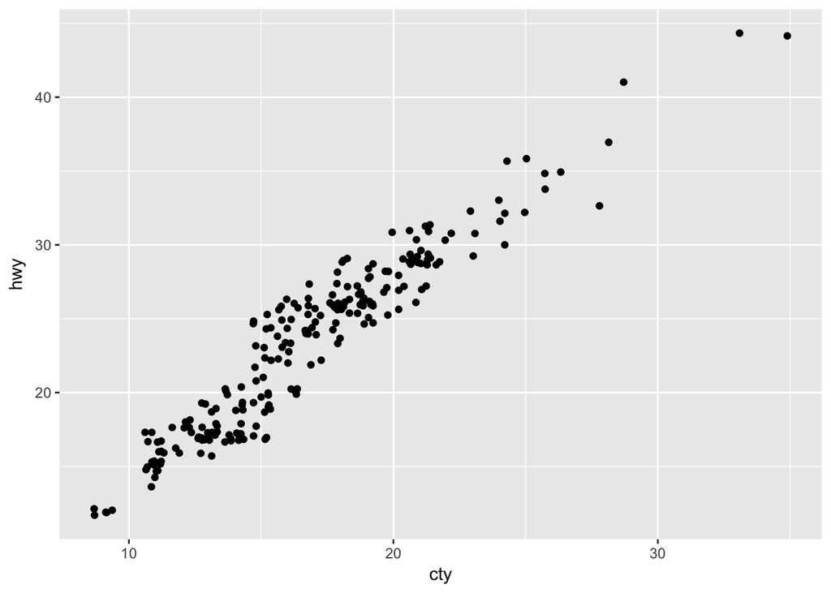

```r
ggplot(data = mpg, mapping = aes(x = cty, y = hwy)) +
  geom_jitter()
```

2. What parameters to geom_jitter() control the amount of jittering? Width and height control the amount of vertical and horizontal jitter.
3. Compare and contrast geom_jitter() with geom_count().

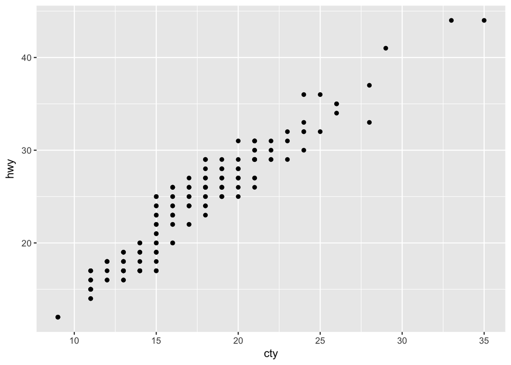

```r
ggplot(mpg, aes(cty, hwy)) +
  geom_point()
```

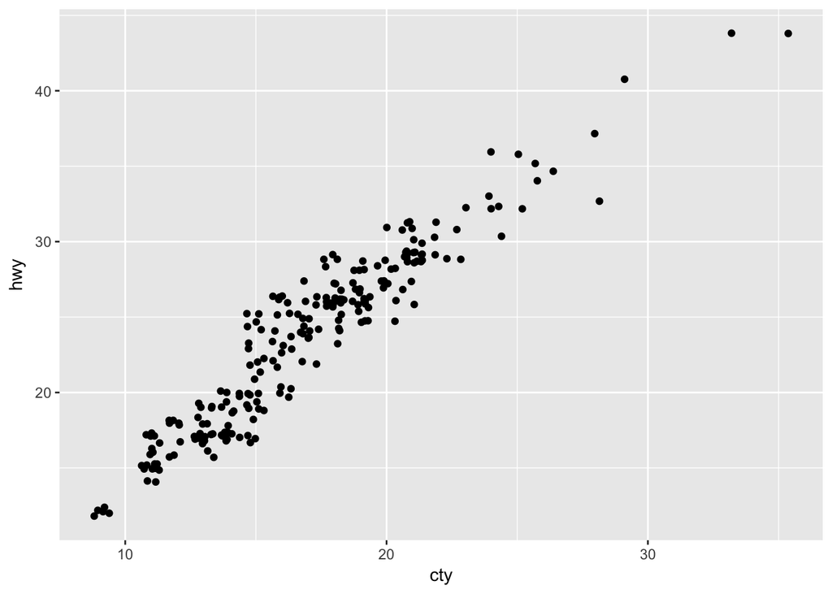

```r
ggplot(mpg, aes(cty, hwy)) +
  geom_jitter()
```

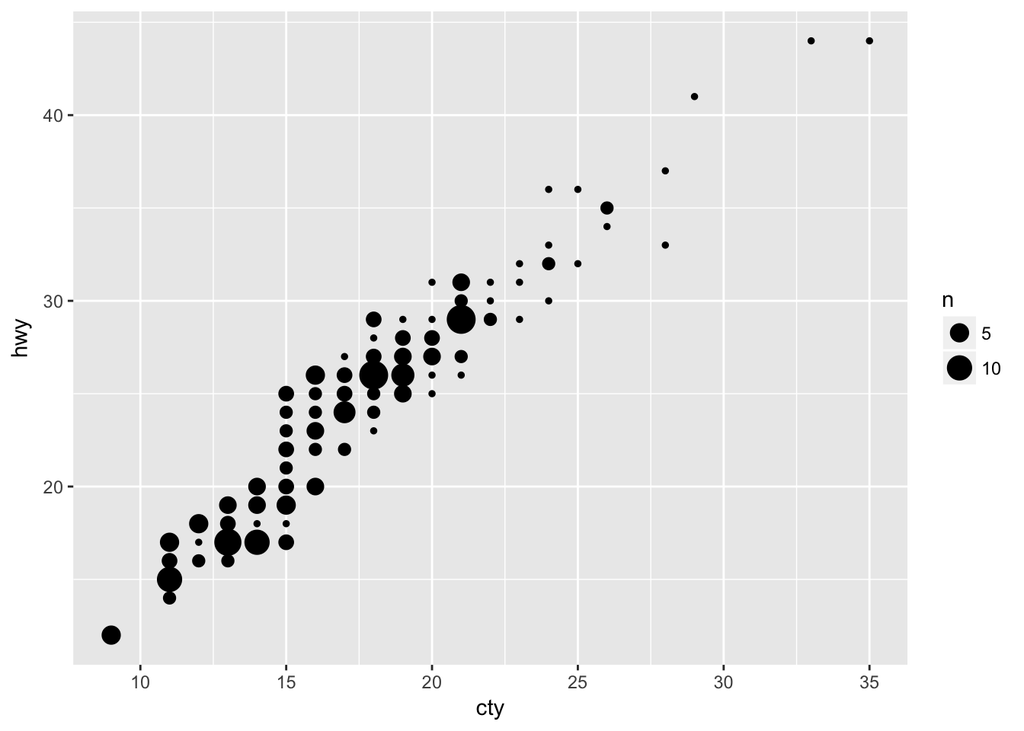

```r
ggplot(mpg, aes(cty, hwy)) +
  geom_count()
```

geom_count() is a variant geom_point that counts the number of observations at each location, then maps the count to point area. It useful when you have discrete data and overplotting. for geom_jitter, the width and height of the point indicates the density while for geom_count, the size of the point is a discrete variable

4. What is the default position adjustment for geom_boxplot()? Create a visualisation of the mpg dataset that demonstrates it.

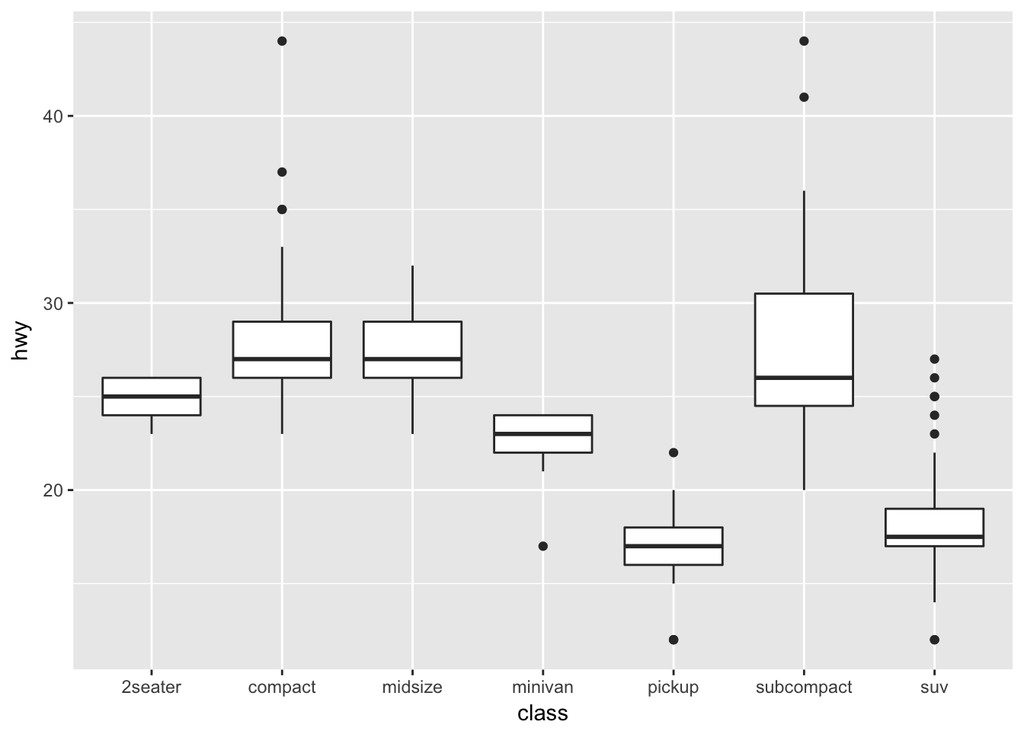

```r
ggplot(mpg, aes(class, hwy,group=class)) +
  geom_boxplot(position = "dodge")
```

it is position_dodge()

## 1.5 1.4 - 3.9.1

1. Turn a stacked bar chart into a pie chart using coord_polar().

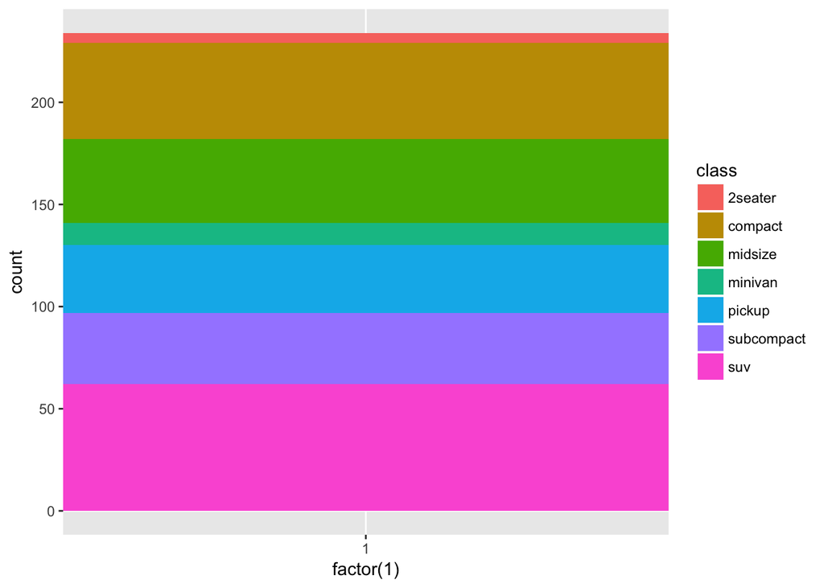

```r
ggplot(data = mpg, mapping = aes(x = factor(1), fill = class)) +
  geom_bar(width = 1)
```

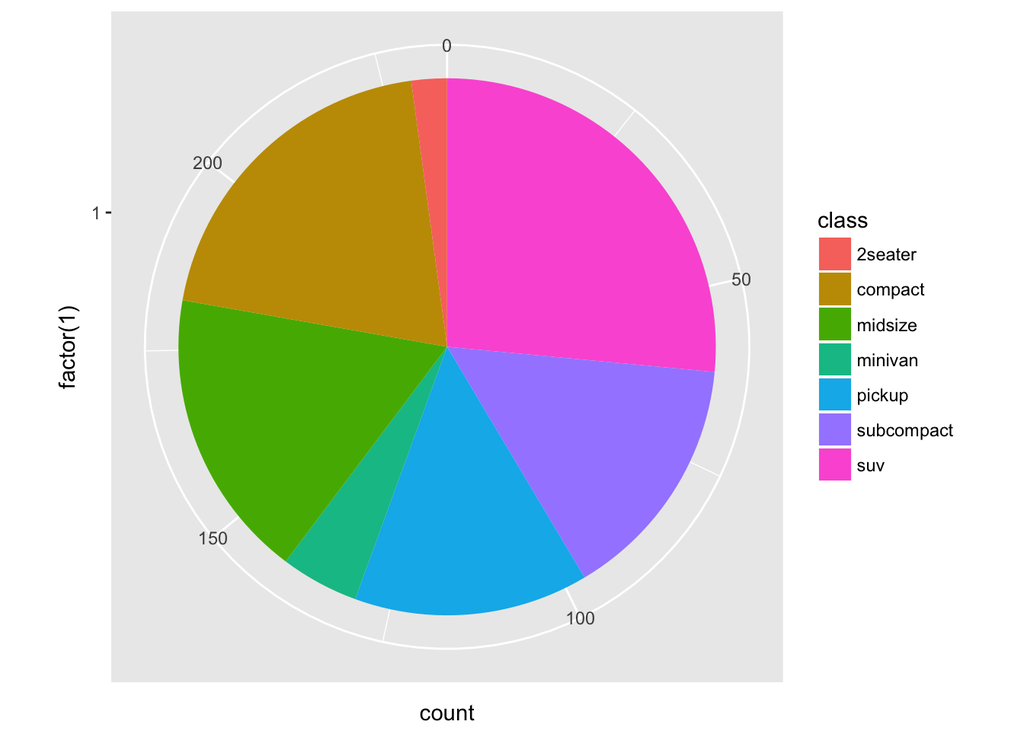

```r
ggplot(data = mpg, mapping = aes(x = factor(1), fill = class)) +
  geom_bar(width = 1) +
  coord_polar(theta = "y")
```

2. What does labs() do? Read the documentation.

we can add title, subtitle and caption.

3. What???s the difference between coord_quickmap() and coord_map()? coord_map projects a portion of the earth, which is approximately spherical, onto a flat 2D plane using any projection defined by the mapproj package. Map projections do not, in general, preserve straight lines, so this requires considerable computation. coord_quickmap is a quick approximation that does preserve straight lines. It works best for smaller areas closer to the equator.

install.packages(“mapproj”) nz <- map_data(“nz”)

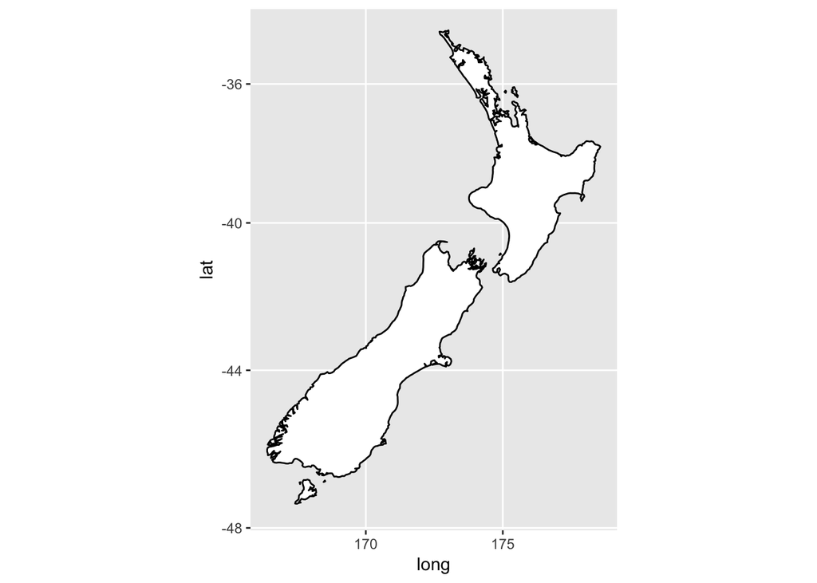

```r
nz <- map_data("nz")
nzmap <- ggplot(nz, aes(x = long, y = lat, group = group)) +
  geom_polygon(fill = "white", colour = "black")
nzmap + coord_map()
```

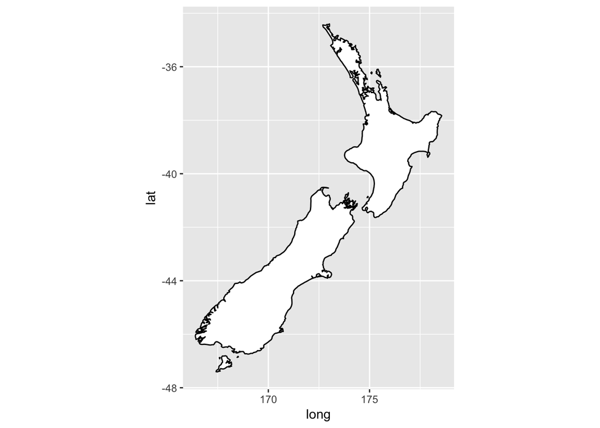

```r
nzmap + coord_quickmap()
```

4. What does the plot below tell you about the relationship between city and highway mpg? Why is coord_fixed() important? What does geom_abline() do?

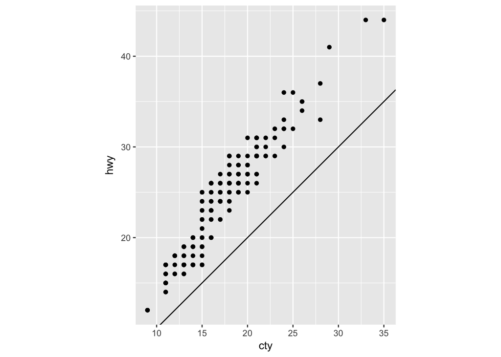

```r
ggplot(data = mpg, mapping = aes(x = cty, y = hwy)) +
geom_point() +
geom_abline() +
coord_fixed()
```

the relationship between city and highway is linear with slope higher than 1.

coord_fixed(), A fixed scale coordinate system forces a specified ratio between the physical representation of data units on the axes. The ratio represents the number of units on the y-axis equivalent to one unit on the x-axis. The default, ratio = 1, ensures that one unit on the x-axis is the same length as one unit on the y-axis.

geom_abline() add reference lines and default is intercept 0 and slope 1. this is useful as this line shows that the data has linear relationship with slope slightly higher than 1.

## 1.6 1.5 - 4.4

problem in spelling, in second one “i” is replaced by some other letter

2. Tweak each of the following R commands so that they run correctly: library(tidyverse) ggplot(dota = mpg) + geom_point(mapping = aes(x = displ, y = hwy)) fliter(mpg, cyl = 8) filter(diamond, carat > 3)

```r
library("tidyverse")
```

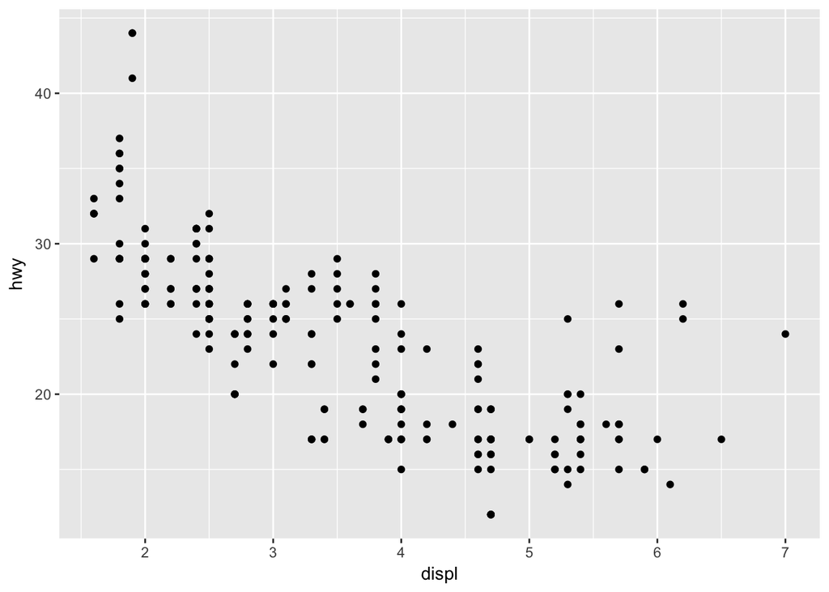

```r
ggplot(data = mpg) +
  geom_point(mapping = aes(x = displ, y = hwy))
```

```r
filter(mpg, cyl == 8)
```

```
## # A tibble: 70 x 11
##    manufa~ model    displ  year   cyl trans  drv     cty   hwy fl    class
##    <chr>   <chr>    <dbl> <int> <int> <chr>  <chr> <int> <int> <chr> <chr>
##  1 audi    a6 quat~  4.20  2008     8 auto(~ 4        16    23 p     mids~
##  2 chevro~ c1500 s~  5.30  2008     8 auto(~ r        14    20 r     suv
##  3 chevro~ c1500 s~  5.30  2008     8 auto(~ r        11    15 e     suv
##  4 chevro~ c1500 s~  5.30  2008     8 auto(~ r        14    20 r     suv
##  5 chevro~ c1500 s~  5.70  1999     8 auto(~ r        13    17 r     suv
##  6 chevro~ c1500 s~  6.00  2008     8 auto(~ r        12    17 r     suv
##  7 chevro~ corvette  5.70  1999     8 manua~ r        16    26 p     2sea~
##  8 chevro~ corvette  5.70  1999     8 auto(~ r        15    23 p     2sea~
##  9 chevro~ corvette  6.20  2008     8 manua~ r        16    26 p     2sea~
## 10 chevro~ corvette  6.20  2008     8 auto(~ r        15    25 p     2sea~
## # ... with 60 more rows
```

```r
filter(diamonds, carat > 3)
```

```
## # A tibble: 32 x 10
##    carat cut     color clarity depth table price     x     y     z
##    <dbl> <ord>   <ord> <ord>   <dbl> <dbl> <int> <dbl> <dbl> <dbl>
##  1  3.01 Premium I     I1       62.7  58.0  8040  9.10  8.97  5.67
##  2  3.11 Fair    J     I1       65.9  57.0  9823  9.15  9.02  5.98
##  3  3.01 Premium F     I1       62.2  56.0  9925  9.24  9.13  5.73
##  4  3.05 Premium E     I1       60.9  58.0 10453  9.26  9.25  5.66
##  5  3.02 Fair    I     I1       65.2  56.0 10577  9.11  9.02  5.91
##  6  3.01 Fair    H     I1       56.1  62.0 10761  9.54  9.38  5.31
##  7  3.65 Fair    H     I1       67.1  53.0 11668  9.53  9.48  6.38
##  8  3.24 Premium H     I1       62.1  58.0 12300  9.44  9.40  5.85
##  9  3.22 Ideal   I     I1       62.6  55.0 12545  9.49  9.42  5.92
## 10  3.50 Ideal   H     I1       62.8  57.0 12587  9.65  9.59  6.03
## # ... with 22 more rows
```

3. Press Alt + Shift + K. What happens? How can you get to the same place using the menus? keyboard shortcut quick reference Tools - keyboard shortcut help

## 1.7 1.6 - 5.2.4

Using the nycflights13 library, find all flights that

1. Had an arrival delay of two or more hours

```r
library(nycflights13)
nycflights <- nycflights13::flights
filter(nycflights, arr_delay >= 120)
```

```
## # A tibble: 10,200 x 19
##     year month   day dep_~ sche~ dep_~ arr_~ sche~ arr_~ carr~ flig~ tail~
##    <int> <int> <int> <int> <int> <dbl> <int> <int> <dbl> <chr> <int> <chr>
##  1  2013     1     1   811   630 101    1047   830   137 MQ     4576 N531~
##  2  2013     1     1   848  1835 853    1001  1950   851 MQ     3944 N942~
##  3  2013     1     1   957   733 144    1056   853   123 UA      856 N534~
##  4  2013     1     1  1114   900 134    1447  1222   145 UA     1086 N765~
##  5  2013     1     1  1505  1310 115    1638  1431   127 EV     4497 N179~
##  6  2013     1     1  1525  1340 105    1831  1626   125 B6      525 N231~
##  7  2013     1     1  1549  1445  64.0  1912  1656   136 EV     4181 N211~
##  8  2013     1     1  1558  1359 119    1718  1515   123 EV     5712 N826~
##  9  2013     1     1  1732  1630  62.0  2028  1825   123 EV     4092 N169~
## 10  2013     1     1  1803  1620 103    2008  1750   138 MQ     4622 N504~
## # ... with 10,190 more rows, and 7 more variables: origin <chr>,
## #   dest <chr>, air_time <dbl>, distance <dbl>, hour <dbl>, minute <dbl>,
## #   time_hour <dttm>
```

2. Flew to Houston (IAH or HOU)

```r
filter(nycflights, dest == "IAH" | dest =="HOU")
```

```
## # A tibble: 9,313 x 19
##     year month   day dep_t~ sched~ dep_de~ arr_~ sche~ arr_de~ carr~ flig~
##    <int> <int> <int>  <int>  <int>   <dbl> <int> <int>   <dbl> <chr> <int>
##  1  2013     1     1    517    515    2.00   830   819   11.0  UA     1545
##  2  2013     1     1    533    529    4.00   850   830   20.0  UA     1714
##  3  2013     1     1    623    627 -  4.00   933   932    1.00 UA      496
##  4  2013     1     1    728    732 -  4.00  1041  1038    3.00 UA      473
##  5  2013     1     1    739    739    0     1104  1038   26.0  UA     1479
##  6  2013     1     1    908    908    0     1228  1219    9.00 UA     1220
##  7  2013     1     1   1028   1026    2.00  1350  1339   11.0  UA     1004
##  8  2013     1     1   1044   1045 -  1.00  1352  1351    1.00 UA      455
##  9  2013     1     1   1114    900  134     1447  1222  145    UA     1086
## 10  2013     1     1   1205   1200    5.00  1503  1505 -  2.00 UA     1461
## # ... with 9,303 more rows, and 8 more variables: tailnum <chr>,
## #   origin <chr>, dest <chr>, air_time <dbl>, distance <dbl>, hour <dbl>,
## #   minute <dbl>, time_hour <dttm>
```

3. Were operated by United, American, or Delta

```r
filter(nycflights, carrier == "UA" | carrier =="AA" | carrier =="DL")
```

```
## # A tibble: 139,504 x 19
##     year month   day dep_t~ sched_~ dep_d~ arr_~ sched~ arr_d~ carr~ flig~
##    <int> <int> <int>  <int>   <int>  <dbl> <int>  <int>  <dbl> <chr> <int>
##  1  2013     1     1    517     515   2.00   830    819  11.0  UA     1545
##  2  2013     1     1    533     529   4.00   850    830  20.0  UA     1714
##  3  2013     1     1    542     540   2.00   923    850  33.0  AA     1141
##  4  2013     1     1    554     600  -6.00   812    837 -25.0  DL      461
##  5  2013     1     1    554     558  -4.00   740    728  12.0  UA     1696
##  6  2013     1     1    558     600  -2.00   753    745   8.00 AA      301
##  7  2013     1     1    558     600  -2.00   924    917   7.00 UA      194
##  8  2013     1     1    558     600  -2.00   923    937 -14.0  UA     1124
##  9  2013     1     1    559     600  -1.00   941    910  31.0  AA      707
## 10  2013     1     1    559     600  -1.00   854    902 - 8.00 UA     1187
## # ... with 139,494 more rows, and 8 more variables: tailnum <chr>,
## #   origin <chr>, dest <chr>, air_time <dbl>, distance <dbl>, hour <dbl>,
## #   minute <dbl>, time_hour <dttm>
```

4. Departed in summer (July, August, and September)

```r
filter(nycflights, month == 7 | month == 8 | month == 9)
```

```
## # A tibble: 86,326 x 19
##     year month   day dep_t~ sched_~ dep_de~ arr_~ sched~ arr_~ carr~ flig~
##    <int> <int> <int>  <int>   <int>   <dbl> <int>  <int> <dbl> <chr> <int>
##  1  2013     7     1      1    2029  212      236   2359   157 B6      915
##  2  2013     7     1      2    2359    3.00   344    344     0 B6     1503
##  3  2013     7     1     29    2245  104      151      1   110 B6      234
##  4  2013     7     1     43    2130  193      322     14   188 B6     1371
##  5  2013     7     1     44    2150  174      300    100   120 AA      185
##  6  2013     7     1     46    2051  235      304   2358   186 B6      165
##  7  2013     7     1     48    2001  287      308   2305   243 VX      415
##  8  2013     7     1     58    2155  183      335     43   172 B6      425
##  9  2013     7     1    100    2146  194      327     30   177 B6     1183
## 10  2013     7     1    100    2245  135      337    135   122 B6      623
## # ... with 86,316 more rows, and 8 more variables: tailnum <chr>,
## #   origin <chr>, dest <chr>, air_time <dbl>, distance <dbl>, hour <dbl>,
## #   minute <dbl>, time_hour <dttm>
```

5. Arrived more than two hours late, but didn’t leave late

```r
filter(nycflights, dep_delay <= 0 & arr_delay > 120)
```

```
## # A tibble: 29 x 19
##     year month   day dep_~ sche~ dep_~ arr_~ sche~ arr_~ carr~ flig~ tail~
##    <int> <int> <int> <int> <int> <dbl> <int> <int> <dbl> <chr> <int> <chr>
##  1  2013     1    27  1419  1420 -1.00  1754  1550   124 MQ     3728 N1EA~
##  2  2013    10     7  1350  1350  0     1736  1526   130 EV     5181 N611~
##  3  2013    10     7  1357  1359 -2.00  1858  1654   124 AA     1151 N3CM~
##  4  2013    10    16   657   700 -3.00  1258  1056   122 B6        3 N703~
##  5  2013    11     1   658   700 -2.00  1329  1015   194 VX      399 N629~
##  6  2013     3    18  1844  1847 -3.00    39  2219   140 UA      389 N560~
##  7  2013     4    17  1635  1640 -5.00  2049  1845   124 MQ     4540 N721~
##  8  2013     4    18   558   600 -2.00  1149   850   179 AA      707 N3EX~
##  9  2013     4    18   655   700 -5.00  1213   950   143 AA     2083 N565~
## 10  2013     5    22  1827  1830 -3.00  2217  2010   127 MQ     4674 N518~
## # ... with 19 more rows, and 7 more variables: origin <chr>, dest <chr>,
## #   air_time <dbl>, distance <dbl>, hour <dbl>, minute <dbl>,
## #   time_hour <dttm>
```

6. Were delayed by at least an hour, but made up over 30 minutes in flight

```r
filter(nycflights, dep_delay >= 60 & arr_delay < dep_delay - 30)
```

```
## # A tibble: 1,844 x 19
##     year month   day dep_t~ sched_~ dep_d~ arr_~ sched~ arr_d~ carr~ flig~
##    <int> <int> <int>  <int>   <int>  <dbl> <int>  <int>  <dbl> <chr> <int>
##  1  2013     1     1   2205    1720  285      46   2040 246    AA     1999
##  2  2013     1     1   2326    2130  116     131     18  73.0  B6      199
##  3  2013     1     3   1503    1221  162    1803   1555 128    UA      551
##  4  2013     1     3   1839    1700   99.0  2056   1950  66.0  AA      575
##  5  2013     1     3   1850    1745   65.0  2148   2120  28.0  AA      177
##  6  2013     1     3   1941    1759  102    2246   2139  67.0  UA      979
##  7  2013     1     3   1950    1845   65.0  2228   2227   1.00 B6       91
##  8  2013     1     3   2015    1915   60.0  2135   2111  24.0  9E     3525
##  9  2013     1     3   2257    2000  177      45   2224 141    9E     3439
## 10  2013     1     4   1917    1700  137    2135   1950 105    AA      575
## # ... with 1,834 more rows, and 8 more variables: tailnum <chr>,
## #   origin <chr>, dest <chr>, air_time <dbl>, distance <dbl>, hour <dbl>,
## #   minute <dbl>, time_hour <dttm>
```

7. Departed between midnight and 6am (inclusive)

```r
filter(nycflights, dep_time<600 | dep_time >= 0)
```

```
## # A tibble: 328,521 x 19
##     year month   day dep_t~ sched_~ dep_d~ arr_~ sched~ arr_d~ carr~ flig~
##    <int> <int> <int>  <int>   <int>  <dbl> <int>  <int>  <dbl> <chr> <int>
##  1  2013     1     1    517     515   2.00   830    819  11.0  UA     1545
##  2  2013     1     1    533     529   4.00   850    830  20.0  UA     1714
##  3  2013     1     1    542     540   2.00   923    850  33.0  AA     1141
##  4  2013     1     1    544     545  -1.00  1004   1022 -18.0  B6      725
##  5  2013     1     1    554     600  -6.00   812    837 -25.0  DL      461
##  6  2013     1     1    554     558  -4.00   740    728  12.0  UA     1696
##  7  2013     1     1    555     600  -5.00   913    854  19.0  B6      507
##  8  2013     1     1    557     600  -3.00   709    723 -14.0  EV     5708
##  9  2013     1     1    557     600  -3.00   838    846 - 8.00 B6       79
## 10  2013     1     1    558     600  -2.00   753    745   8.00 AA      301
## # ... with 328,511 more rows, and 8 more variables: tailnum <chr>,
## #   origin <chr>, dest <chr>, air_time <dbl>, distance <dbl>, hour <dbl>,
## #   minute <dbl>, time_hour <dttm>
```

2. Another useful dplyr filtering helper is between(). What does it do? Can you use it to simplify theccode needed to answer the previous challenges?

```r
filter(nycflights, between(month, 7, 9))
```

```
## # A tibble: 86,326 x 19
##     year month   day dep_t~ sched_~ dep_de~ arr_~ sched~ arr_~ carr~ flig~
##    <int> <int> <int>  <int>   <int>   <dbl> <int>  <int> <dbl> <chr> <int>
##  1  2013     7     1      1    2029  212      236   2359   157 B6      915
##  2  2013     7     1      2    2359    3.00   344    344     0 B6     1503
##  3  2013     7     1     29    2245  104      151      1   110 B6      234
##  4  2013     7     1     43    2130  193      322     14   188 B6     1371
##  5  2013     7     1     44    2150  174      300    100   120 AA      185
##  6  2013     7     1     46    2051  235      304   2358   186 B6      165
##  7  2013     7     1     48    2001  287      308   2305   243 VX      415
##  8  2013     7     1     58    2155  183      335     43   172 B6      425
##  9  2013     7     1    100    2146  194      327     30   177 B6     1183
## 10  2013     7     1    100    2245  135      337    135   122 B6      623
## # ... with 86,316 more rows, and 8 more variables: tailnum <chr>,
## #   origin <chr>, dest <chr>, air_time <dbl>, distance <dbl>, hour <dbl>,
## #   minute <dbl>, time_hour <dttm>
```

```r
filter(nycflights, between(dep_time, 0, 600))
```

```
## # A tibble: 9,344 x 19
##     year month   day dep_t~ sched_~ dep_d~ arr_~ sched~ arr_d~ carr~ flig~
##    <int> <int> <int>  <int>   <int>  <dbl> <int>  <int>  <dbl> <chr> <int>
##  1  2013     1     1    517     515   2.00   830    819  11.0  UA     1545
##  2  2013     1     1    533     529   4.00   850    830  20.0  UA     1714
##  3  2013     1     1    542     540   2.00   923    850  33.0  AA     1141
##  4  2013     1     1    544     545  -1.00  1004   1022 -18.0  B6      725
##  5  2013     1     1    554     600  -6.00   812    837 -25.0  DL      461
##  6  2013     1     1    554     558  -4.00   740    728  12.0  UA     1696
##  7  2013     1     1    555     600  -5.00   913    854  19.0  B6      507
##  8  2013     1     1    557     600  -3.00   709    723 -14.0  EV     5708
##  9  2013     1     1    557     600  -3.00   838    846 - 8.00 B6       79
## 10  2013     1     1    558     600  -2.00   753    745   8.00 AA      301
## # ... with 9,334 more rows, and 8 more variables: tailnum <chr>,
## #   origin <chr>, dest <chr>, air_time <dbl>, distance <dbl>, hour <dbl>,
## #   minute <dbl>, time_hour <dttm>
```

3. How many flights have a missing dep_time? What other variables are missing? What might these rows represent?

```r
filter(nycflights, is.na(dep_time))
```

```
## # A tibble: 8,255 x 19
##     year month   day dep_~ sche~ dep_~ arr_~ sche~ arr_~ carr~ flig~ tail~
##    <int> <int> <int> <int> <int> <dbl> <int> <int> <dbl> <chr> <int> <chr>
##  1  2013     1     1    NA  1630    NA    NA  1815    NA EV     4308 N181~
##  2  2013     1     1    NA  1935    NA    NA  2240    NA AA      791 N3EH~
##  3  2013     1     1    NA  1500    NA    NA  1825    NA AA     1925 N3EV~
##  4  2013     1     1    NA   600    NA    NA   901    NA B6      125 N618~
##  5  2013     1     2    NA  1540    NA    NA  1747    NA EV     4352 N105~
##  6  2013     1     2    NA  1620    NA    NA  1746    NA EV     4406 N139~
##  7  2013     1     2    NA  1355    NA    NA  1459    NA EV     4434 N105~
##  8  2013     1     2    NA  1420    NA    NA  1644    NA EV     4935 N759~
##  9  2013     1     2    NA  1321    NA    NA  1536    NA EV     3849 N135~
## 10  2013     1     2    NA  1545    NA    NA  1910    NA AA      133 <NA>
## # ... with 8,245 more rows, and 7 more variables: origin <chr>,
## #   dest <chr>, air_time <dbl>, distance <dbl>, hour <dbl>, minute <dbl>,
## #   time_hour <dttm>
```

8255 flights.

```r
for (Var in names(nycflights)) {
    missing <- sum(is.na(nycflights[,Var]))
    if (missing > 0) {
        print(c(Var,missing))
    }
}
```

```
## [1] "dep_time" "8255"
## [1] "dep_delay" "8255"
## [1] "arr_time" "8713"
## [1] "arr_delay" "9430"
## [1] "tailnum" "2512"
## [1] "air_time" "9430"
```

variables with missing values are: [1] “dep_time” “8255”  
[1] “dep_delay” “8255”  
[1] “arr_time” “8713”  
[1] “arr_delay” “9430”  
[1] “tailnum” “2512”  
[1] “air_time” “9430”

4. Why is NA ?? 0 not missing? Why is NA | TRUE not missing? Why is FALSE & NA not missing? Can you figure out the general rule? (NA * 0 is a tricky counterexample!)

NA ^ 0 - na to the 0th power is 1.  
NA | TRUE - condition is TRUE, the result is TRUE  
FALSE & NA - there’s no value that satisfies this, but it is recorded as 0 results rather than missing  
NA is missing value.so NA * 0 is NA.

## 1.8 1.7 - 5.3.1

1. How could you use arrange() to sort all missing values to the start? (Hint: use is.na()).

```r
arrange(nycflights, !is.na(dep_time))
```

```
## # A tibble: 336,776 x 19
##     year month   day dep_~ sche~ dep_~ arr_~ sche~ arr_~ carr~ flig~ tail~
##    <int> <int> <int> <int> <int> <dbl> <int> <int> <dbl> <chr> <int> <chr>
##  1  2013     1     1    NA  1630    NA    NA  1815    NA EV     4308 N181~
##  2  2013     1     1    NA  1935    NA    NA  2240    NA AA      791 N3EH~
##  3  2013     1     1    NA  1500    NA    NA  1825    NA AA     1925 N3EV~
##  4  2013     1     1    NA   600    NA    NA   901    NA B6      125 N618~
##  5  2013     1     2    NA  1540    NA    NA  1747    NA EV     4352 N105~
##  6  2013     1     2    NA  1620    NA    NA  1746    NA EV     4406 N139~
##  7  2013     1     2    NA  1355    NA    NA  1459    NA EV     4434 N105~
##  8  2013     1     2    NA  1420    NA    NA  1644    NA EV     4935 N759~
##  9  2013     1     2    NA  1321    NA    NA  1536    NA EV     3849 N135~
## 10  2013     1     2    NA  1545    NA    NA  1910    NA AA      133 <NA>
## # ... with 336,766 more rows, and 7 more variables: origin <chr>,
## #   dest <chr>, air_time <dbl>, distance <dbl>, hour <dbl>, minute <dbl>,
## #   time_hour <dttm>
```

2. Sort flights to find the most delayed flights by arrival time.

```r
arrange(nycflights, desc(arr_delay))
```

```
## # A tibble: 336,776 x 19
##     year month   day dep_~ sche~ dep_~ arr_~ sche~ arr_~ carr~ flig~ tail~
##    <int> <int> <int> <int> <int> <dbl> <int> <int> <dbl> <chr> <int> <chr>
##  1  2013     1     9   641   900  1301  1242  1530  1272 HA       51 N384~
##  2  2013     6    15  1432  1935  1137  1607  2120  1127 MQ     3535 N504~
##  3  2013     1    10  1121  1635  1126  1239  1810  1109 MQ     3695 N517~
##  4  2013     9    20  1139  1845  1014  1457  2210  1007 AA      177 N338~
##  5  2013     7    22   845  1600  1005  1044  1815   989 MQ     3075 N665~
##  6  2013     4    10  1100  1900   960  1342  2211   931 DL     2391 N959~
##  7  2013     3    17  2321   810   911   135  1020   915 DL     2119 N927~
##  8  2013     7    22  2257   759   898   121  1026   895 DL     2047 N671~
##  9  2013    12     5   756  1700   896  1058  2020   878 AA      172 N5DM~
## 10  2013     5     3  1133  2055   878  1250  2215   875 MQ     3744 N523~
## # ... with 336,766 more rows, and 7 more variables: origin <chr>,
## #   dest <chr>, air_time <dbl>, distance <dbl>, hour <dbl>, minute <dbl>,
## #   time_hour <dttm>
```

3. Find the flights that left earliest relative to their scheduled departure.

```r
arrange(nycflights, dep_delay)
```

```
## # A tibble: 336,776 x 19
##     year month   day dep_t~ sched_~ dep_d~ arr_~ sched~ arr_d~ carr~ flig~
##    <int> <int> <int>  <int>   <int>  <dbl> <int>  <int>  <dbl> <chr> <int>
##  1  2013    12     7   2040    2123  -43.0    40   2352  48.0  B6       97
##  2  2013     2     3   2022    2055  -33.0  2240   2338 -58.0  DL     1715
##  3  2013    11    10   1408    1440  -32.0  1549   1559 -10.0  EV     5713
##  4  2013     1    11   1900    1930  -30.0  2233   2243 -10.0  DL     1435
##  5  2013     1    29   1703    1730  -27.0  1947   1957 -10.0  F9      837
##  6  2013     8     9    729     755  -26.0  1002    955   7.00 MQ     3478
##  7  2013    10    23   1907    1932  -25.0  2143   2143   0    EV     4361
##  8  2013     3    30   2030    2055  -25.0  2213   2250 -37.0  MQ     4573
##  9  2013     3     2   1431    1455  -24.0  1601   1631 -30.0  9E     3318
## 10  2013     5     5    934     958  -24.0  1225   1309 -44.0  B6      375
## # ... with 336,766 more rows, and 8 more variables: tailnum <chr>,
## #   origin <chr>, dest <chr>, air_time <dbl>, distance <dbl>, hour <dbl>,
## #   minute <dbl>, time_hour <dttm>
```

4. Sort flights to find the shortest amount of time actually in the air.

```r
arrange(nycflights, air_time)
```

```
## # A tibble: 336,776 x 19
##     year month   day dep_t~ sched_~ dep_d~ arr_~ sched~ arr_d~ carr~ flig~
##    <int> <int> <int>  <int>   <int>  <dbl> <int>  <int>  <dbl> <chr> <int>
##  1  2013     1    16   1355    1315  40.0   1442   1411  31.0  EV     4368
##  2  2013     4    13    537     527  10.0    622    628 - 6.00 EV     4631
##  3  2013    12     6    922     851  31.0   1021    954  27.0  EV     4276
##  4  2013     2     3   2153    2129  24.0   2247   2224  23.0  EV     4619
##  5  2013     2     5   1303    1315 -12.0   1342   1411 -29.0  EV     4368
##  6  2013     2    12   2123    2130 - 7.00  2211   2225 -14.0  EV     4619
##  7  2013     3     2   1450    1500 -10.0   1547   1608 -21.0  US     2132
##  8  2013     3     8   2026    1935  51.0   2131   2056  35.0  9E     3650
##  9  2013     3    18   1456    1329  87.0   1533   1426  67.0  EV     4118
## 10  2013     3    19   2226    2145  41.0   2305   2246  19.0  EV     4276
## # ... with 336,766 more rows, and 8 more variables: tailnum <chr>,
## #   origin <chr>, dest <chr>, air_time <dbl>, distance <dbl>, hour <dbl>,
## #   minute <dbl>, time_hour <dttm>
```

## 1.9 1.8 - 5.4.1

1. Brainstorm as many ways as possible to select dep_time, dep_delay, arr_time, and arr_delay from flights.

```r
select(flights, dep_time, dep_delay, arr_time, arr_delay)
```

```
## # A tibble: 336,776 x 4
##    dep_time dep_delay arr_time arr_delay
##       <int>     <dbl>    <int>     <dbl>
##  1      517      2.00      830     11.0
##  2      533      4.00      850     20.0
##  3      542      2.00      923     33.0
##  4      544     -1.00     1004    -18.0
##  5      554     -6.00      812    -25.0
##  6      554     -4.00      740     12.0
##  7      555     -5.00      913     19.0
##  8      557     -3.00      709    -14.0
##  9      557     -3.00      838    - 8.00
## 10      558     -2.00      753      8.00
## # ... with 336,766 more rows
```

```r
select(flights, starts_with("dep"), starts_with("arr"))
```

```
## # A tibble: 336,776 x 4
##    dep_time dep_delay arr_time arr_delay
##       <int>     <dbl>    <int>     <dbl>
##  1      517      2.00      830     11.0
##  2      533      4.00      850     20.0
##  3      542      2.00      923     33.0
##  4      544     -1.00     1004    -18.0
##  5      554     -6.00      812    -25.0
##  6      554     -4.00      740     12.0
##  7      555     -5.00      913     19.0
##  8      557     -3.00      709    -14.0
##  9      557     -3.00      838    - 8.00
## 10      558     -2.00      753      8.00
## # ... with 336,766 more rows
```

```r
select(flights, dep_time, arr_time, ends_with("delay"))
```

```
## # A tibble: 336,776 x 4
##    dep_time arr_time dep_delay arr_delay
##       <int>    <int>     <dbl>     <dbl>
##  1      517      830      2.00     11.0
##  2      533      850      4.00     20.0
##  3      542      923      2.00     33.0
##  4      544     1004     -1.00    -18.0
##  5      554      812     -6.00    -25.0
##  6      554      740     -4.00     12.0
##  7      555      913     -5.00     19.0
##  8      557      709     -3.00    -14.0
##  9      557      838     -3.00    - 8.00
## 10      558      753     -2.00      8.00
## # ... with 336,766 more rows
```

```r
select(flights, dep_time, arr_time, contains("delay"))
```

```
## # A tibble: 336,776 x 4
##    dep_time arr_time dep_delay arr_delay
##       <int>    <int>     <dbl>     <dbl>
##  1      517      830      2.00     11.0
##  2      533      850      4.00     20.0
##  3      542      923      2.00     33.0
##  4      544     1004     -1.00    -18.0
##  5      554      812     -6.00    -25.0
##  6      554      740     -4.00     12.0
##  7      555      913     -5.00     19.0
##  8      557      709     -3.00    -14.0
##  9      557      838     -3.00    - 8.00
## 10      558      753     -2.00      8.00
## # ... with 336,766 more rows
```

2. What happens if you include the name of a variable multiple times in a select() call?

```r
select(flights, dep_time, dep_time, dep_time, dep_time)
```

```
## # A tibble: 336,776 x 1
##    dep_time
##       <int>
##  1      517
##  2      533
##  3      542
##  4      544
##  5      554
##  6      554
##  7      555
##  8      557
##  9      557
## 10      558
## # ... with 336,766 more rows
```

no difference with the case with the variable included only one time

3. What does the one_of() function do? Why might it be helpful in conjunction with this vector?

```r
vars <- c("year", "month", "day", "dep_delay", "arr_delay")
select(nycflights, one_of(vars))
```

```
## # A tibble: 336,776 x 5
##     year month   day dep_delay arr_delay
##    <int> <int> <int>     <dbl>     <dbl>
##  1  2013     1     1      2.00     11.0
##  2  2013     1     1      4.00     20.0
##  3  2013     1     1      2.00     33.0
##  4  2013     1     1     -1.00    -18.0
##  5  2013     1     1     -6.00    -25.0
##  6  2013     1     1     -4.00     12.0
##  7  2013     1     1     -5.00     19.0
##  8  2013     1     1     -3.00    -14.0
##  9  2013     1     1     -3.00    - 8.00
## 10  2013     1     1     -2.00      8.00
## # ... with 336,766 more rows
```

it selects variables with matching names in the list

4. Does the result of running the following code surprise you? How do the select helpers deal with case by default? How can you change that default?

```r
select(nycflights, contains("TIME"))
```

```
## # A tibble: 336,776 x 6
##    dep_time sched_dep_time arr_time sched_arr_~ air_t~ time_hour
##       <int>          <int>    <int>       <int>  <dbl> <dttm>
##  1      517            515      830         819  227   2013-01-01 05:00:00
##  2      533            529      850         830  227   2013-01-01 05:00:00
##  3      542            540      923         850  160   2013-01-01 05:00:00
##  4      544            545     1004        1022  183   2013-01-01 05:00:00
##  5      554            600      812         837  116   2013-01-01 06:00:00
##  6      554            558      740         728  150   2013-01-01 05:00:00
##  7      555            600      913         854  158   2013-01-01 06:00:00
##  8      557            600      709         723   53.0 2013-01-01 06:00:00
##  9      557            600      838         846  140   2013-01-01 06:00:00
## 10      558            600      753         745  138   2013-01-01 06:00:00
## # ... with 336,766 more rows
```

by default, case is insensitive.

we can change it to:

```r
select(nycflights, contains("TIME", ignore.case = FALSE))
```

```
## # A tibble: 336,776 x 0
```

## 1.10 1.9 - 5.5.2

1. Currently dep_time and sched_dep_time are convenient to look at, but hard to compute with because they???re not really continuous numbers. Convert them to a more convenient representation of number of minutes since midnight.

```r
transmute(nycflights, dep_time = floor(dep_time / 100) * 60 + (dep_time - floor(dep_time /100) * 100), sched_dep_time = floor(sched_dep_time / 100) * 60 + (sched_dep_time - floor(sched_dep_time /100) * 100))
```

```
## # A tibble: 336,776 x 2
##    dep_time sched_dep_time
##       <dbl>          <dbl>
##  1      317            315
##  2      333            329
##  3      342            340
##  4      344            345
##  5      354            360
##  6      354            358
##  7      355            360
##  8      357            360
##  9      357            360
## 10      358            360
## # ... with 336,766 more rows
```

2. Compare air_time with arr_time - dep_time. What do you expect to see? What do you see? What do you need to do to fix it?

```r
nycflights_airtime <- select(flights, air_time, arr_time, dep_time)
mutate(nycflights_airtime, air_time2 = arr_time - dep_time)
```

```
## # A tibble: 336,776 x 4
##    air_time arr_time dep_time air_time2
##       <dbl>    <int>    <int>     <int>
##  1    227        830      517       313
##  2    227        850      533       317
##  3    160        923      542       381
##  4    183       1004      544       460
##  5    116        812      554       258
##  6    150        740      554       186
##  7    158        913      555       358
##  8     53.0      709      557       152
##  9    140        838      557       281
## 10    138        753      558       195
## # ... with 336,766 more rows
```

they don’t correspond to each other, because arr_time and dep_time are recorded in clock time and air_time is recorded in minute. we need to convert them into minite.

3. Implement your fix. Remake the plot from the previous question.

```r
nycflights_mintime <- transmute(nycflights, dep_time = floor(dep_time / 100) * 60 + (dep_time - floor(dep_time /100) * 100), arr_time = floor(arr_time / 100) * 60 + (arr_time - floor(arr_time /100) * 100), air_time)

nycflights_mintime <- mutate(nycflights_mintime, air_time2 = arr_time - dep_time)
```

4. Suggest and justify with words an error tolerance in minutes, meaning that if air_time is too far off from arr_time - dep_time then we assume one of the columns contains an error. After implementing your fix, what fraction of observations still appear to have an error?

```r
nycflights_mintime <- mutate(nycflights_mintime, diff = air_time2 - air_time)
```

1. first we need to consider time difference.
2. An error tolerance is 15 minutes because to be counted as delay, min 15 min has to pass compared to schduled time.
3. Compare dep_time, sched_dep_time, and dep_delay. How would you expect those three numbers to be related? after changing their forms into min like what we did in the previous problem, we should expect: dep_time = sched_dep_time + dep_delay
4. Find the 10 most delayed flights using a ranking function. How do you want to handle ties? Carefully read the documentation for min_rank().

```r
delay_rank <- mutate(nycflights, delay = min_rank(desc(arr_delay)))
arrange(delay_rank, delay)
```

```
## # A tibble: 336,776 x 20
##     year month   day dep_~ sche~ dep_~ arr_~ sche~ arr_~ carr~ flig~ tail~
##    <int> <int> <int> <int> <int> <dbl> <int> <int> <dbl> <chr> <int> <chr>
##  1  2013     1     9   641   900  1301  1242  1530  1272 HA       51 N384~
##  2  2013     6    15  1432  1935  1137  1607  2120  1127 MQ     3535 N504~
##  3  2013     1    10  1121  1635  1126  1239  1810  1109 MQ     3695 N517~
##  4  2013     9    20  1139  1845  1014  1457  2210  1007 AA      177 N338~
##  5  2013     7    22   845  1600  1005  1044  1815   989 MQ     3075 N665~
##  6  2013     4    10  1100  1900   960  1342  2211   931 DL     2391 N959~
##  7  2013     3    17  2321   810   911   135  1020   915 DL     2119 N927~
##  8  2013     7    22  2257   759   898   121  1026   895 DL     2047 N671~
##  9  2013    12     5   756  1700   896  1058  2020   878 AA      172 N5DM~
## 10  2013     5     3  1133  2055   878  1250  2215   875 MQ     3744 N523~
## # ... with 336,766 more rows, and 8 more variables: origin <chr>,
## #   dest <chr>, air_time <dbl>, distance <dbl>, hour <dbl>, minute <dbl>,
## #   time_hour <dttm>, delay <int>
```

```r
delay_rank <- mutate(nycflights, delay = row_number(desc(arr_delay)))
arrange(delay_rank, delay)
```

```
## # A tibble: 336,776 x 20
##     year month   day dep_~ sche~ dep_~ arr_~ sche~ arr_~ carr~ flig~ tail~
##    <int> <int> <int> <int> <int> <dbl> <int> <int> <dbl> <chr> <int> <chr>
##  1  2013     1     9   641   900  1301  1242  1530  1272 HA       51 N384~
##  2  2013     6    15  1432  1935  1137  1607  2120  1127 MQ     3535 N504~
##  3  2013     1    10  1121  1635  1126  1239  1810  1109 MQ     3695 N517~
##  4  2013     9    20  1139  1845  1014  1457  2210  1007 AA      177 N338~
##  5  2013     7    22   845  1600  1005  1044  1815   989 MQ     3075 N665~
##  6  2013     4    10  1100  1900   960  1342  2211   931 DL     2391 N959~
##  7  2013     3    17  2321   810   911   135  1020   915 DL     2119 N927~
##  8  2013     7    22  2257   759   898   121  1026   895 DL     2047 N671~
##  9  2013    12     5   756  1700   896  1058  2020   878 AA      172 N5DM~
## 10  2013     5     3  1133  2055   878  1250  2215   875 MQ     3744 N523~
## # ... with 336,766 more rows, and 8 more variables: origin <chr>,
## #   dest <chr>, air_time <dbl>, distance <dbl>, hour <dbl>, minute <dbl>,
## #   time_hour <dttm>, delay <int>
```

row_number: ties.method is first min_rank: ties.method is min but in this case these two yield the same outcome

7. What does 1:3 + 1:10 return? Why?

```r
 1:3 + 1:10
```

```
##  [1]  2  4  6  5  7  9  8 10 12 11
```

Two vectors are not of the same length, so the first vector is added multiple times

# 2 2 Public Sector Application: Flight Data

## 2.1 2.1 Download BTS data

```r
setwd('/Users/JihyeJang/Downloads/pset 1')
```

??? Read it into R using chi.flights <- read_csv(“data.csv”) and use the bind_rows command to stitch together the monthly files into a yearlong file.

```r
chi.flights1 <- read_csv("856185449_T_ONTIME.csv")
chi.flights2 <- read_csv("856185449_T_ONTIME 2.csv")
chi.flights3 <- read_csv("856185449_T_ONTIME 3.csv")
chi.flights4 <- read_csv("856185449_T_ONTIME 4.csv")
chi.flights5 <- read_csv("856185449_T_ONTIME 5.csv")
chi.flights6 <- read_csv("856185449_T_ONTIME 6.csv")
chi.flights7 <- read_csv("856185449_T_ONTIME 7.csv")
chi.flights8 <- read_csv("856185449_T_ONTIME 8.csv")
chi.flights9 <- read_csv("856185449_T_ONTIME 9.csv")
chi.flights10 <- read_csv("856185449_T_ONTIME 10.csv")
chi.flights11 <- read_csv("856185449_T_ONTIME 11.csv")
chi.flights12 <- read_csv("856185449_T_ONTIME 12.csv")
chi_flights <- bind_rows(chi.flights1, chi.flights2, chi.flights3, chi.flights4, chi.flights5, chi.flights6, chi.flights7, chi.flights8, chi.flights9, chi.flights10, chi.flights11, chi.flights12)
```

## 2.2 2.2 Data Description

1. What is the unique identifier for each flight in the dataset? There is no exisiting unique identifier for each flight in the dataset, but we can consturct one with flight date, carrier number and flight number.
2. R has six description methods: print, head, str, glimpse, View, summary. Apply them to chi_flights
3. Are any of the methods redundant, in the sense that you don???t learn anything from these commands that you didn???t already know from the prior methods? Make a list of the non-redundant methods

non-redundant: print / str / View / summary head and glimpse are redundant because it is similar to print but show no new information

2. Of the non-redundant methods, say one thing that you learned about the data from each method.
1. print shows classes variables (incomplete) and numbers of rows and columns
2. str shows every variables as opposed to print and head
3. View shows the data d.summary shows length, class and other statistical characteristics like mean, max and median
3. Propose a short cheat sheet (max 2 lines per command) for the non-redundant methods
1. print(x, …) different method for class ‘factor’, ‘table’ and ‘function’
2. str(object, …)
3. View(x, title)
4. summary(object, …)

## 2.3 2.3 Data Validation

1. You should have 675822 rows when you downloaded data for Illinois. Load the package testthat and then test that you have this many rows using the command test_that(expect_equal(nrows(data),675822))

install.packages(“testthat”)

```r
library("testthat")
test_that("row number test", {
  expect_equal(nrow(chi_flights),675822)
})
```

2. Because of the conditions you put into the webform, all flights should be to or from Illinois airports. Let???s check this.

```r
orig_dest <- subset(chi_flights, select = c(ORIGIN_STATE_ABR, DEST_STATE_ABR))

filter(orig_dest, ORIGIN_STATE_ABR == "IL" | DEST_STATE_ABR == "IL")
```

```
## # A tibble: 675,822 x 2
##    ORIGIN_STATE_ABR DEST_STATE_ABR
##    <chr>            <chr>
##  1 CA               IL
##  2 CA               IL
##  3 CA               IL
##  4 IL               CA
##  5 IL               CA
##  6 IL               CA
##  7 IL               CA
##  8 IL               CA
##  9 IL               CA
## 10 IL               CA
## # ... with 675,812 more rows
```

It is 675,822 rows so we proved that all flights are to or from Illinois airports.

3. Drop flights to Midway and Ohare. How many flights are left?

```r
chi_flights2 <- filter(chi_flights, DEST == "ORD" | DEST == "MDW")
```

4. Among flights whose origin or destination is not Midway or Ohare, what are the five most common origins? What are the five most common destinations? Where are these cities? Are these origins and destinations inside or outside Illinois? Can you explain why these are the most common origins and destinations?

```r
nonchi_flights <- filter(chi_flights, (ORIGIN != "ORD" & ORIGIN != "MDW") & (DEST != "ORD" & DEST != "MDW") )
```

12240 observations.

install.packages(“plyr”)

```r
library("plyr")
count(nonchi_flights, 'ORIGIN')
```

```
##    ORIGIN freq
## 1     ATL 2966
## 2     BMI 1517
## 3     DEN  126
## 4     DFW  655
## 5     DTW 1233
## 6     IAH   89
## 7     MLI 1984
## 8     MSP 1021
## 9     PIA 2001
## 10    SPI  648
```

```r
count(nonchi_flights, 'DEST')
```

```
##    DEST freq
## 1   ATL 2968
## 2   BMI 1517
## 3   DEN  186
## 4   DFW  656
## 5   DTW 1228
## 6   IAH   90
## 7   MLI 1926
## 8   MSP 1022
## 9   PIA 1999
## 10  SPI  648
```

five most common origins are ATL, PIA, MLI, BMI, DTW five most common destinations are ATL, PIA, MLI, BMI, DTW Atlanta, Peoria, Moline, Bloomington/Normal,Detroit Atlanta and Detroit are outside of IL.

5. Next, limit the sample to flights to or from Midway and Ohare.
6. How many rows do you think the dataset should have, approximately? Find at least two websites that estimate the number of flights into each airport. Do these estimates agree with what is in the BTS dataset? Do these estimates agree with each other? If they disagree, why do you think they disagree?

```r
chicago <- filter(chi_flights, ORIGIN == "ORD" | DEST =="ORD" | DEST == "MDW" | ORIGIN == "MDW")
```

663582 rows.

Two websites: 1)Bureau of transportation statistics https://www.transtats.bts.gov/airports.asp?pn=1 2)Chicago department of Aviation. http://www.flychicago.com/business/CDA/factsfigures/Pages/airtraffic.aspx They are slightly different. because bureau of transportation statistics only shows the scheduled flight numbers as opposed to actually delivered flight numbers.

6. Google to figure out the three highest-volume airlines at Ohare and the three highest-volume airlines out of Midway. Does this agree with what you find in the BTS data? If they disagree, why do you think they disagree?

From Bureau of Statistics:

Midway:Southwest(WN), Delta(DL), ExpressJet (EV)

```r
MDW_outflights <- filter(chi_flights, ORIGIN == "MDW")
ORD_outflights <- filter(chi_flights, ORIGIN == "ORD")
```

```r
count(MDW_outflights, 'CARRIER')
```

```
##   CARRIER  freq
## 1      DL  2583
## 2      EV   972
## 3      OO   631
## 4      WN 83623
```

```r
count(ORD_outflights, 'CARRIER')
```

```
##    CARRIER  freq
## 1       AA 61988
## 2       AS  2024
## 3       B6  2425
## 4       DL  7614
## 5       EV 40865
## 6       F9  4598
## 7       NK 10597
## 8       OO 41691
## 9       UA 70771
## 10      VX  1509
```